# Applied web scraping and natural language processing in analysis of BMJ obituary pages

National NHS-R Community Conference, 11th November 2020

## Introduction

- British Medical Journal (BMJ) publishes obituaries on medical figures who have recently died
- Written in prose, but always containing same variables
- name, dob, date of death, cause of death, specialty, number of children, qualifying university, professional affiliations.
- *Aim: automate the extraction of meaningful data from free text on a publically available website?*

## Methodology - Sample webpage

[interactive chart not shown]

## Methodology - Sample webpage

[figure not shown]

## Previous work

- Wright et. al (1996) used a sample of 572 obituaries, finding that doctors born in the Indian subcontinent die earlier than those born in the United Kingdom.
- Patel et al. (2009) used 3342 obituaries to describe that primary care doctors can expect to live 20 years longer than an emergency medicine doctor.

## Methodology - What is web-scraping

Getting data off a website in a systematic way, can involve:

- Copy-Paste
- HTML Parsing: using HTML structure "tags" to pull out target
- API

## Methodology - API example

```r
library(twitteR)

consumer_key <- "ricFTD***********"
consumer_secret <- "HDLtx5Cs******************************"
access_token <- "832653309873836**************************"
access_secret <- "LjfqToHoXssOw************************"

#hashed out as passwords truncated:
#setup_twitter_oauth(consumer_key, consumer_secret, access_token, access_secret)

#fn_twitter <- searchTwitter("medtwitter",n=50000,lang="en")
```

But what if there is no API?

## Methodology - Scraping HTML using R

```r
#Loading the rvest package
library(rvest)
#Define URL
url <- 'https://www.bmj.com/news/obituary'

#Extract HTML
webpage <- read_html(url)
```

## Methodology - Using HTML tags to target scrape

[interactive chart not shown]

## Methodology - Extracting variables from prose

Useful techniques in our case

- stemming
- lemmatisation
- repetitive phrases e.g. "died from", "leaves behind"

## Methodology - Natural language processing in R

Packages include

- koRpus
- quanteda

## Results

- 8156 obituaries accessed between 1997-2019
- 84.5% male
- average age at death 79 years
- Lowest age at death 58.7 (emergency medicine), oldest 80.3 (primary care)
- Just 3.4% of all surgeons were women
- Cancer was a more common cause of death (39%) than heart and circulatory (27%, bucks trend for UK population)

## Results - Relative survival analysis

```r
library(relsurv)
```

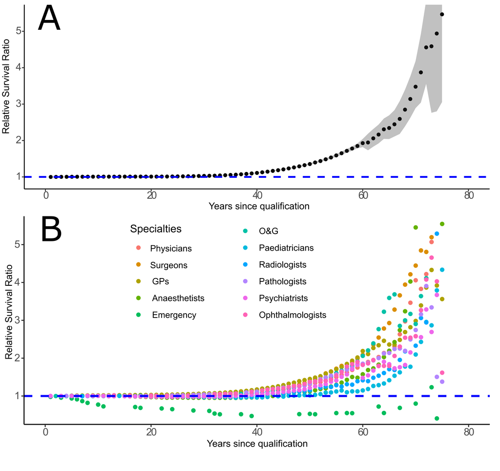

## Limitations

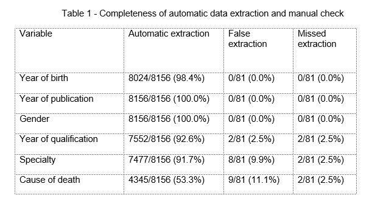

## Key points

- There is lots of quality data online
- Web scraping is easy and can make these data accessible
- Automated analysis is extremely accurate for simple variables, but performs worse with more complex variables
- Machine learning could improve on this performance
- Our study presents the largest ever analysis of medical obituary data

## Acknowledgements/References

- BMJ
- R and associated packages

References

- Wright DJ, Roberts AP. Which doctors die first? Analysis of BMJ obituary columns. BMJ. 1996 Dec 21;313(7072):1581-2.
- Patel K, Yan YM, Patel K, Judge P, Patel J, Johal S, Johal S, Do P, Leyva F. Lifespan and cardiology. British journal of cardiology. 2009;16(6):299-302.

## Thank you

```r
print("Any questions?")
```

```
## [1] "Any questions?"
```